# IODS course project

Joni Haikonen

# Introduction to Open Data Science - Course Project

# About the project

```r
# This is a so-called "R chunk" where you can write R code.

date()
```

```
## [1] "Mon Dec 12 19:21:55 2022"
```

Data is an infinite emptiness, much like the Buddhist conception of Sunyata - by itself it speaks of nothing and the ways to interpret it are equally innumerable. It is only when we approach the endless sea of data and its interpretations with some kind of defined framework of meaning, that the data begins to speak to us. The Science of Data is therefore about wrangling infinite non-sense into momentary finite sense, of drawing a bucket of water from the ocean. What I aim to learn in this course is precisely this, our attempts at grasping the ungraspable.

As for the initial exercises, I am not certain of what I gained and didn’t gain from them. Code is not easily learned by merely running something someone else has written, coding can be only learned by writing the arguments yourself. Exercise Set 1 provides a useful overview of some basics of course but if one were to ask me to write anything elaborate in R at this moment, I would cower back into the books. It is also difficult to gauge what was difficult and what was not at this stage, as I am merely reading and pressing Ctrl + Enter in RStudio, attempting to understand the logic by which R speaks. I didn’t feel particularly challenged by anything but simultaneously I didn’t feel I got a solid grasp of anything either. I think the solidity will only arrive once I get to do the dirty work myself. To some extent the basics seem rather simple and clear but I am certain I will still be rather slow at the start, as the exercises get more complicated - but I suppose it is a welcome challenge.The couple of exercises in chapters 3 and 4 helped a little bit to get some feeling for using R yourself, if one didn’t look at the solutions right away.

https://github.com/Voidlessness/IODS-project

# Analysis exercise

```r
date()
```

```
## [1] "Mon Dec 12 19:21:55 2022"
```

In the following, I present some basic data visualization and regression modelling, done to an analysis dataset created in the “data wrangling” exercise. The dataset consists of students during a statistics course responding to a questionnaire about learning statistics. The statements posed to the students take on values from 1-5, depending on how much they agree with the statement, 1 being total disagreement and 5 being total agreement. The questions are further divided in the data to deep, strategic and surface questions (abbreviated as deep, stra and surf, respectively. These values have been averaged in the data below. Further, the data consists of the gender of each student, their age, attitude toward statistics and the test score points (named Points) they got at the end of the statistics course. The idea is now to explore which of these variables, if any, significantly may have contributed to the final points score the students got on their test and to see if, using linear regression modelling, we can predict which of the variables may contribute to test success.

Linear regression essentially compares a dependent variable of our choosing - in this case the test score Points - to one or multiple explanatory variables (e.g the various types of questions, gender, age etc.) in order to test if there is a linear/causal relationship between these variables. I will present the code I have used and in the comments above the code attempt to explain what I have done and what the results obtained mean.

```r
# Here I load tidyverse, read the analysis dataset made in the Data wrangling exercise, explore the dimensions of the data using str() and head(), and create a basic table showing all the variables.
library(tidyverse)
read.csv(file = 'C:/IODS/IODS-project/data/analysis_dataset.csv')
```

```
##     gender Age attitude     deep  stra     surf Points
## 1        F  53      3.7 3.583333 3.375 2.583333     25
## 2        M  55      3.1 2.916667 2.750 3.166667     12
## 3        F  49      2.5 3.500000 3.625 2.250000     24
## 4        M  53      3.5 3.500000 3.125 2.250000     10
## 5        M  49      3.7 3.666667 3.625 2.833333     22
## 6        F  38      3.8 4.750000 3.625 2.416667     21
## 7        M  50      3.5 3.833333 2.250 1.916667     21
## 8        F  37      2.9 3.250000 4.000 2.833333     31
## 9        M  37      3.8 4.333333 4.250 2.166667     24
## 10       F  42      2.1 4.000000 3.500 3.000000     26
## 11       M  37      3.9 3.583333 3.625 2.666667     31
## 12       F  34      3.8 3.833333 4.750 2.416667     31
## 13       F  34      2.4 4.250000 3.625 2.250000     23
## 14       F  34      3.0 3.333333 3.500 2.750000     25
```

[output cut: 152 more lines]

```r
analysis_dataset <- read.csv(file = 'C:/IODS/IODS-project/data/analysis_dataset.csv')
str(analysis_dataset)
```

```
## 'data.frame':    166 obs. of  7 variables:
##  $ gender  : chr  "F" "M" "F" "M" ...
##  $ Age     : int  53 55 49 53 49 38 50 37 37 42 ...
##  $ attitude: num  3.7 3.1 2.5 3.5 3.7 3.8 3.5 2.9 3.8 2.1 ...
##  $ deep    : num  3.58 2.92 3.5 3.5 3.67 ...
##  $ stra    : num  3.38 2.75 3.62 3.12 3.62 ...
##  $ surf    : num  2.58 3.17 2.25 2.25 2.83 ...
##  $ Points  : int  25 12 24 10 22 21 21 31 24 26 ...
```

```r
head(analysis_dataset)
```

```
##   gender Age attitude     deep  stra     surf Points
## 1      F  53      3.7 3.583333 3.375 2.583333     25
## 2      M  55      3.1 2.916667 2.750 3.166667     12
## 3      F  49      2.5 3.500000 3.625 2.250000     24
## 4      M  53      3.5 3.500000 3.125 2.250000     10
## 5      M  49      3.7 3.666667 3.625 2.833333     22
## 6      F  38      3.8 4.750000 3.625 2.416667     21
```

```r
analysis_dataset
```

```
##     gender Age attitude     deep  stra     surf Points
## 1        F  53      3.7 3.583333 3.375 2.583333     25
## 2        M  55      3.1 2.916667 2.750 3.166667     12
## 3        F  49      2.5 3.500000 3.625 2.250000     24
## 4        M  53      3.5 3.500000 3.125 2.250000     10
## 5        M  49      3.7 3.666667 3.625 2.833333     22
## 6        F  38      3.8 4.750000 3.625 2.416667     21
## 7        M  50      3.5 3.833333 2.250 1.916667     21
## 8        F  37      2.9 3.250000 4.000 2.833333     31
## 9        M  37      3.8 4.333333 4.250 2.166667     24
## 10       F  42      2.1 4.000000 3.500 3.000000     26
## 11       M  37      3.9 3.583333 3.625 2.666667     31
## 12       F  34      3.8 3.833333 4.750 2.416667     31
## 13       F  34      2.4 4.250000 3.625 2.250000     23
## 14       F  34      3.0 3.333333 3.500 2.750000     25
```

[output cut: 152 more lines]

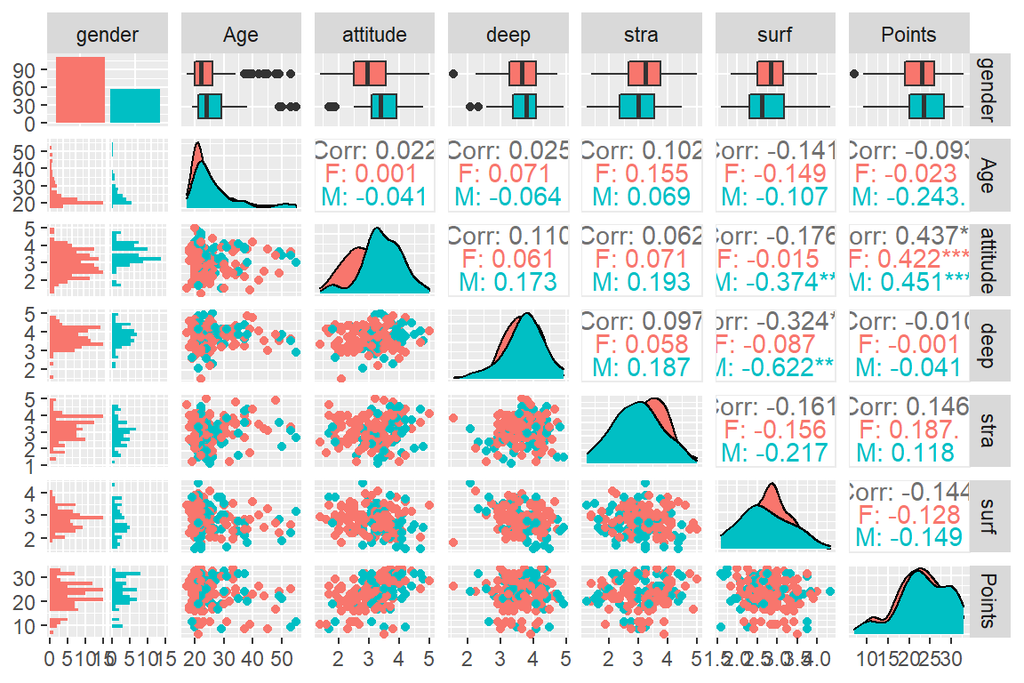

```r
# This is the visual overview of the data, done by creating a scatterplot matrix using ggplot2 and Ggally. A plot "p" is created by using the ggpairs command, within which we specify the data we are wanting to visualize, and how we wish to map it and present it. With the aes() command, we specify that we especially want to visually separate the gender variable with two colors, seen below. Below the code a rather intimidating scatterplot matrix is created. On the first row the matrix shows the distribution of the values in each group in the data, their median, min/max values, possible outliers in the data and the quartiles. Then the plot essentially shows the distribution of each of our values in both genders and how the variables correlate with each other. The distributions are shown both in scatter plots and normal distributions. Finally the graph presents numeric correlation values when comparing the various variables with each other and also shows separate correlation values for different genders. Correlation can take values between -1 to 1, where both extremes note significant correlation between the variables and 0 indicating no correlation.
library(ggplot2)
library (GGally)
p <- ggpairs(analysis_dataset, mapping = aes(col = gender), lower = list(combo = wrap("facethist", bins = 20)))
p
```

```r
# Here a linear regression model is created with the target (dependent) variable being points on the test (Points) and the explanatory variables being attitude, surface level questions and age. First the lm() command prints out "Residuals" which shows the difference between the actual values of the compared variables given in the data and what the linear model would predict them to be based on the input we've given. Next, the coefficients section we first get the "intercept" values. In the case of our data, the "Estimate" for intercept means the average points score on the test expected, when taking into account all the explanatory variables we have selected from the dataset - in this case it amounts to about 16.8 points. Below this are the various slope values for the different explanatory variables we've chosen - the slope describes the effect the various explanatory variables have on the test score. For example a point increase in the "attitude" variable would increase the test scores by 3.42388 points. The Std.error column represents the level of uncertainty with each coefficient - ideally this should be minimal. Next, the t-value is the t-statistic for the dependent variable, calculated as Estimate/Std. Error - it depicts how far our coefficient values are from 0. The further away it is, the stronger the correlation between the dependent and explanatory value. Finally, the "Pr(>|t|)" column represents the p-value for the t-statistic, which tells us the level of significance between the dependent and explanatory values. The p-value should be less that 0.05 to conclude that there is a significant effect between the two variables. In this comparison for example, the variable "attitude" seems to be highly significant when comparing it to the dependent variable "Points", meaning that there is indeed a significant relationship between the attitude of the students during the statistics course and their test scores. In the  In the next R chunk, I remove one of the non-significant variables and run the test again. Next, the residual standard error is a measure of the quality of the regression fit, meaning in this case, how much the average test score points deviate from the regression line fit. The multiple R-squared is yet another measure of how well the linear model fits the actual data, being a measure of the linearity between the dependent variable (Points) and the explanatory variables. R-squared takes on values between 0 to 1, where 0 denotes a non-linear relationship and 1 a total linear relationship. Ideally, we'd like this value to be close to 1 if we wish to conclude that the explanatory variables chosen causally explain changes in the dependent variable. This this case the R-squared value is rather small and close to 0, so the linear fit is not great.
library(GGally)
library(ggplot2)
analysis_model <- lm(Points ~ attitude + surf + Age, data = analysis_dataset)
summary(analysis_model)
```

```
##
## Call:
## lm(formula = Points ~ attitude + surf + Age, data = analysis_dataset)
##
## Residuals:
##     Min      1Q  Median      3Q     Max
## -17.973  -3.430   0.167   3.997  10.444
##
## Coefficients:
##             Estimate Std. Error t value Pr(>|t|)
## (Intercept) 16.85628    3.53786   4.765 4.18e-06 ***
## attitude     3.42388    0.57353   5.970 1.45e-08 ***
## surf        -0.96049    0.79943  -1.201    0.231
## Age         -0.08713    0.05361  -1.625    0.106
## ---
## Signif. codes:  0 '***' 0.001 '**' 0.01 '*' 0.05 '.' 0.1 ' ' 1
##
## Residual standard error: 5.294 on 162 degrees of freedom
## Multiple R-squared:  0.2082, Adjusted R-squared:  0.1935
## F-statistic:  14.2 on 3 and 162 DF,  p-value: 2.921e-08
```

```r
# Here I construct another linear model of the data, but removing "surf" as a non-significant variable.
library(GGally)
library(ggplot2)
analysis_model <- lm(Points ~ attitude + Age, data = analysis_dataset)
summary(analysis_model)
```

```
##
## Call:
## lm(formula = Points ~ attitude + Age, data = analysis_dataset)
##
## Residuals:
##      Min       1Q   Median       3Q      Max
## -17.3354  -3.3095   0.2625   4.0005  10.4911
##
## Coefficients:
##             Estimate Std. Error t value Pr(>|t|)
## (Intercept) 13.57244    2.24943   6.034 1.04e-08 ***
## attitude     3.54392    0.56553   6.267 3.17e-09 ***
## Age         -0.07813    0.05315  -1.470    0.144
## ---
## Signif. codes:  0 '***' 0.001 '**' 0.01 '*' 0.05 '.' 0.1 ' ' 1
##
## Residual standard error: 5.301 on 163 degrees of freedom
## Multiple R-squared:  0.2011, Adjusted R-squared:  0.1913
## F-statistic: 20.52 on 2 and 163 DF,  p-value: 1.125e-08
```

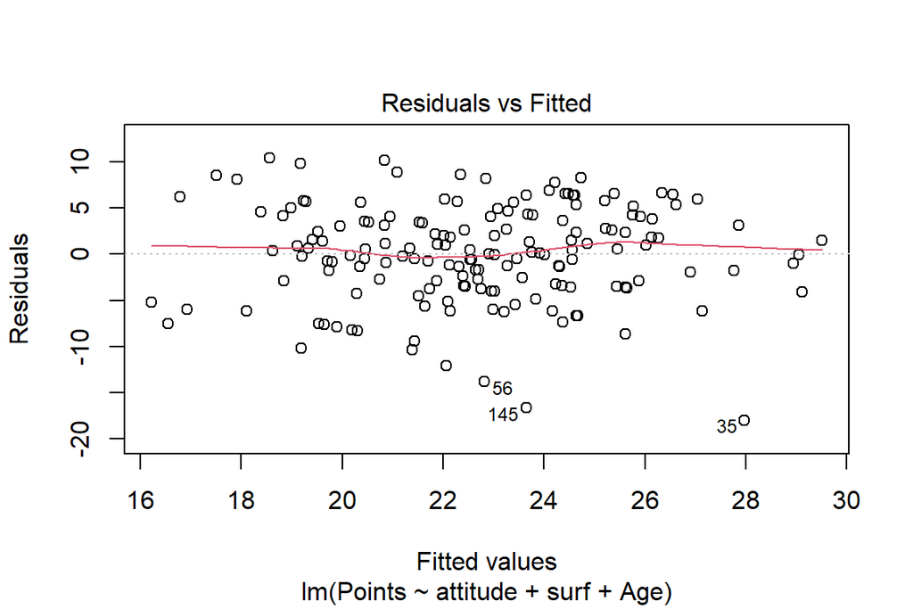

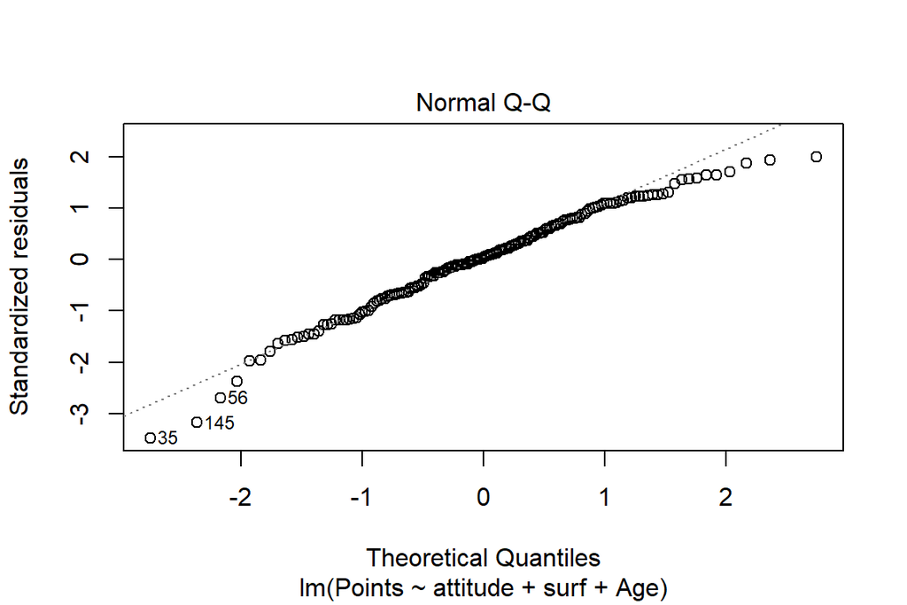

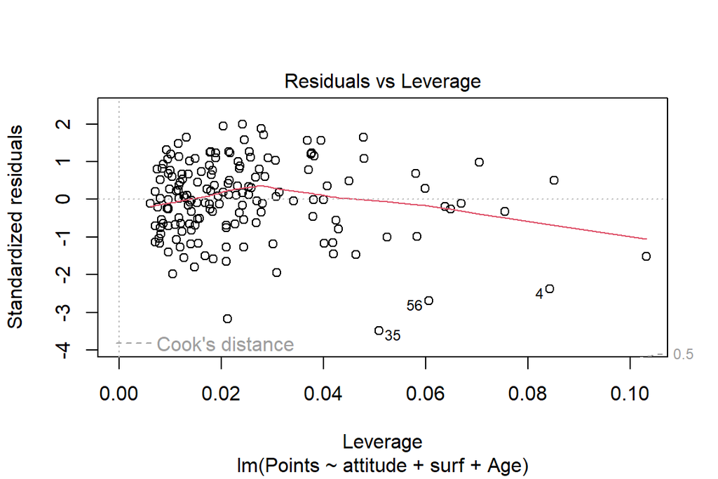

```r
# Finally, several plots are made to graphically estimate the validity of our model assumptions, these plots being "Residual vs. Fitted", "Normal Q-Q" and "Residuals vs Leverage". Residual vs. Fitted shows how closely variables in our chosen parts of the data fit the regression line at 0. The closer they are the better the fit and linearity holds. This plot can also be used to visualize outliers easily, for example data points 56, 145 and 35 seem to stray quite far from the regression line. The Normal Q-Q plot uses the Q1 and Q3 quantiles of the values of each variable to estimate whether or not the values come from a similar distribution (e.g a normal distribution) or not. If they do, they should form a rather straight line, which can be seen in the example data. This is useful when performing statistical significance tests on the data, as many of them may assume for example that the data is normally distributed. The Q-Q plot is an easy way to visualize this quickly and decide whether or not our significance testing methods are appropriate or not. Finally the Residuals vs Leverage once again plots the residuals of our data but this time against leverage. Leverage indicates how much the coefficients in the regression model would change if a any given point of data was removed. The higher the leverage value for a given point of data, the stronger its effect on the coefficients. In the plot "Cook's distance" denotes a region where if a point of data exists there, it would have a highly significant effect on the coefficients if it were removed. In this dataset, however, no points fall within Cook's distance and thereby we can safely assume that no significant outlier is skewing our data.
library(GGally)
library(ggplot2)
analysis_model <- lm(Points ~ attitude + surf + Age, data = analysis_dataset)
plot(analysis_model, which = c(1,2,5))
```

# Analysis exercise 2 - Logistic regression

```r
date()
```

```
## [1] "Mon Dec 12 19:22:02 2022"
```

In this analysis exercise we study a dataset that relates alcohol consumption to student performance in mathematics and Portugese language.

```r
# First reading the data from my local file after the data wrangling exercise. Printing the data for a clear visualization.
library(tidyverse)
alc_data <- read.csv(file = 'C:/IODS/IODS-project/data/alc_data.csv', sep = ",", header = TRUE)
alc_data
```

```
##     school sex age address famsize Pstatus Medu Fedu     Mjob     Fjob
## 1       GP   F  18       U     GT3       A    4    4  at_home  teacher
## 2       GP   F  17       U     GT3       T    1    1  at_home    other
## 3       GP   F  15       U     LE3       T    1    1  at_home    other
## 4       GP   F  15       U     GT3       T    4    2   health services
## 5       GP   F  16       U     GT3       T    3    3    other    other
## 6       GP   M  16       U     LE3       T    4    3 services    other
## 7       GP   M  16       U     LE3       T    2    2    other    other
## 8       GP   F  17       U     GT3       A    4    4    other  teacher
## 9       GP   M  15       U     LE3       A    3    2 services    other
## 10      GP   M  15       U     GT3       T    3    4    other    other
## 11      GP   F  15       U     GT3       T    4    4  teacher   health
## 12      GP   F  15       U     GT3       T    2    1 services    other
## 13      GP   M  15       U     LE3       T    4    4   health services
## 14      GP   M  15       U     GT3       T    4    3  teacher    other
```

[output cut: 1469 more lines]

As can be observed, the data contains multiple variables characterizing each student, as well as their performance in exams (variables G1-3). The task is to select four of these variables and relate them to the variables describing alcohol use, seeing if student performance is significantly affected by alcohol use. For my interest I will compare high alcohol use (high_use) with “health”, “absences”, “failures”, “studytime”, trying to understand whether or not those students that have high alcohol use have diminished health, more absences from class, more failures in class and less studytime. If the data turns out to be this way, I think I could conclude that high alcohol consumptions leads to poorer overall health, which contributes to more absences from class and less study time, which leads to more failure in classes and therefore overall worse performance in class.

First let’s explore the data numerically first by creating a summary table of our chose variables, high alcohol use and the average grades.

```r
alc_data %>% group_by(alc_use, high_use, health, absences, failures, studytime) %>% summarise(count = n(), mean_grade = mean(G3))
```

[output not shown]

```
## # A tibble: 293 × 8
## # Groups:   alc_use, high_use, health, absences, failures [226]
##    alc_use high_use health absences failures studytime count mean_grade
##      <dbl> <lgl>     <int>    <int>    <int>     <int> <int>      <dbl>
##  1       1 FALSE         1        0        0         1     1       10
##  2       1 FALSE         1        0        0         2     5       15
##  3       1 FALSE         1        0        0         3     1       18
##  4       1 FALSE         1        1        0         2     2       10
##  5       1 FALSE         1        2        0         2     4       12.2
##  6       1 FALSE         1        3        0         4     1       12
##  7       1 FALSE         1        4        0         2     2       11.5
##  8       1 FALSE         1        4        0         4     1       10
##  9       1 FALSE         1        6        0         4     1       16
## 10       1 FALSE         1        7        0         2     1       14
## # … with 283 more rows
```

Next, let’s do a few boxplots between our variables, keeping high alcohol use as a constant.

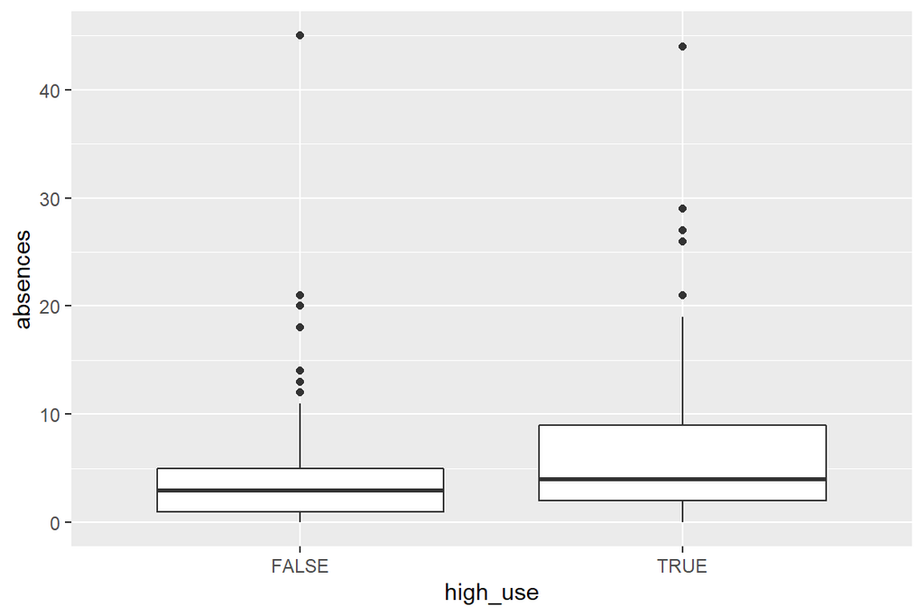

```r
# boxplot of high alcohol use and absences
g1 <- ggplot(alc_data, aes(x = high_use, y = absences))

# drawing the plot and defining it as a boxplot
g1 + geom_boxplot()
```

As can be seen, high alcohol use seems to increase absences from class.

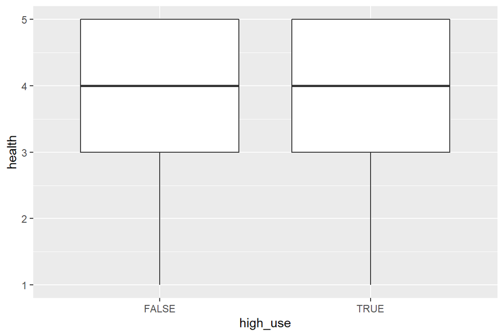

```r
# boxplot of high alcohol use and health
g2 <- ggplot(alc_data, aes(x = high_use, y = health))

# drawing the plot and defining it as a boxplot
g2 + geom_boxplot()
```

Seems that high alcohol use does not in this case correlate with changes in the health score. Strange.

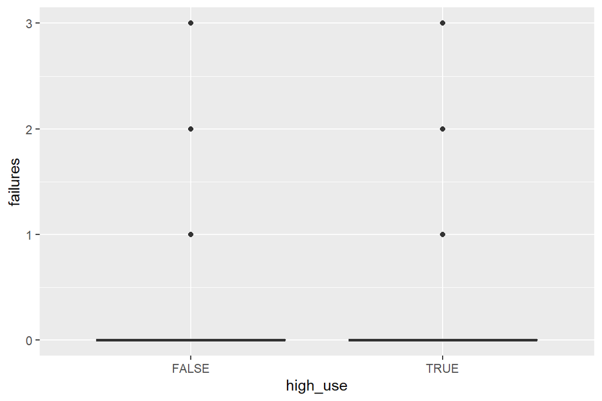

```r
# boxplot of high alcohol use and failures
g3 <- ggplot(alc_data, aes(x = high_use, y = failures))

# drawing the plot and defining it as a boxplot
g3 + geom_boxplot()
```

Again, cannot discern any clear differences. Most of the students had no failures in class, and the few outliers that did don’t seem to differ whether or not they had high alcohol consumption or not.

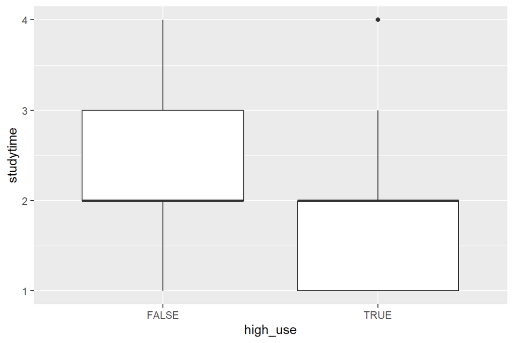

```r
# boxplot of high alcohol use and study time
g4 <- ggplot(alc_data, aes(x = high_use, y = studytime))

# drawing the plot and defining it as a boxplot
g4 + geom_boxplot()
```

Study time seems variable with high alcohol consumption, although the medians seems to be the same. High alcohol consumption seems to reduce studytime, although there also seems to be a lot more variation in the non-high drinkers. Due to the variation, I doubt this difference would be significant.